# Projeto 2 - NLP

# Análise Exploratória

### Vamos analisar as palavras pequenas (1 e 2 caracteres apenas)

```python
# Armazenará as palavras
pequenas = []

'''
Função para preencher a lista de pequenas palavras sem intervir do dado de entrada
'''
def extrai_palavras(texto):
    for palavra in texto.split(' '):
        if len(palavra) < 3:
            pequenas.append(palavra)
    return texto
```

```python
# Cria a lista de palavras
df_analise['tweet_text'].apply(extrai_palavras)
```

```
26477    Gostei de um vídeo @YouTube https://t.co/TBrLM...
9195     Mais uma luta, mais uma Vitória. 👮 #Capitão201...
50030    Candidatos intensificam campanha nas redes soc...
66552     eu fiz dois desenhos hj :D mas não sei se posto.
5862     @peekabruwu desculpa por falar tanto disso ami...
                               ...
52428    @Kizat_Kdust @springwdayy Ela falava do relaci...
4909     Mara Gabrilli rebate Doria e diz que vota em A...
23688    &gt;@brdezoito Bolsonaro repete slogan de Coll...
64356    será q um dia vou conseguir beijar algum dos m...
33463    E que comece o feriadão! 😍 #Work #WorKING #Job...
Name: tweet_text, Length: 80741, dtype: object
```

```python
# Transforma num DataFrame, remove duplicidades e ordena
pd_pequenas = pd.DataFrame(pequenas, columns=['palavra'])
pd_pequenas.drop_duplicates(inplace=True)
pd_pequenas.sort_values(by='palavra', inplace=True)
pequenas = pd_pequenas['palavra'].to_list()
```

```python
pd_pequenas = None    # Não é mais necessário
```

```python
'''
Função para exibir lista de pequenas palavras de forma concisa
'''
def exibir_pequenas(lista):
    col = 1
    idx = 0
    for palavra in lista:
        p = palavra + ' '
        print('{:04}=[{}]'.format(idx, p[0:2]), end=' ')
        idx += 1
        col += 7
        if col >= 70:
            print()
            col = 1
```

```python
exibir_pequenas(pequenas)
```

```
0000=[! ] 0001=[!!] 0002=[!?] 0003=[!”] 0004=[!😢] 0005=[" ] 0006=["-] 0007=["0] 0008=["5] 0009=["A]
0010=["E] 0011=["I] 0012=["N] 0013=["O] 0014=["Y] 0015=["a] 0016=["e] 0017=["n] 0018=["o] 0019=["q]
0020=["À] 0021=["É] 0022=["é] 0023=["ó] 0024=["🙄] 0025=[# ] 0026=[#1] 0027=[#2] 0028=[#3] 0029=[#7]
0030=[#8] 0031=[#a] 0032=[#e] 0033=[#o] 0034=[#é] 0035=[#맘] 0036=[#📷] 0037=[#😉] 0038=[#😜] 0039=[#🙏]
0040=[#🤧] 0041=[$ ] 0042=[$$] 0043=[$,] 0044=[$2] 0045=[$5] 0046=[% ] 0047=[%;] 0048=[' ] 0049=['']
0050=[',] 0051=['7] 0052=['A] 0053=['I] 0054=['O] 0055=['a] 0056=['e] 0057=['o] 0058=['É] 0059=['à]
0060=['é] 0061=[( ] 0062=[((] 0063=[(,] 0064=[(.] 0065=[(/] 0066=[(1] 0067=[(3] 0068=[(7] 0069=[(:]
0070=[(@] 0071=[(A] 0072=[(E] 0073=[(O] 0074=[(Q] 0075=[(a] 0076=[(b] 0077=[(e] 0078=[(n] 0079=[(o]
0080=[(q] 0081=[(É] 0082=[(é] 0083=[(📸] 0084=[) ] 0085=[)!] 0086=[))] 0087=[),] 0088=[).] 0089=[):]
0090=[);] 0091=[)😭] 0092=[* ] 0093=[**] 0094=[*-] 0095=[*A] 0096=[*s] 0097=[+ ] 0098=[++] 0099=[+,]
0100=[+.] 0101=[+1] 0102=[+5] 0103=[+9] 0104=[+:] 0105=[+o] 0106=[, ] 0107=[,,] 0108=[,?] 0109=[,e]
0110=[,n] 0111=[,o] 0112=[,…] 0113=[- ] 0114=[-)] 0115=[--] 0116=[-1] 0117=[-5] 0118=[-:] 0119=[-B]
0120=[-e] 0121=[-f] 0122=[-p] 0123=[-q] 0124=[-⛅] 0125=[-🌞] 0126=[. ] 0127=[.!] 0128=[..] 0129=[.g]
0130=[.ꜜ] 0131=[/ ] 0132=[//] 0133=[/:] 0134=[/p] 0135=[0 ] 0136=[0%] 0137=[0)] 0138=[0,] 0139=[0.]
0140=[0/] 0141=[01] 0142=[02] 0143=[03] 0144=[04] 0145=[05] 0146=[06] 0147=[07] 0148=[08] 0149=[0€]
0150=[1 ] 0151=[1%] 0152=[1)] 0153=[1,] 0154=[1-] 0155=[1.] 0156=[10] 0157=[11] 0158=[12] 0159=[13]
0160=[14] 0161=[15] 0162=[16] 0163=[17] 0164=[18] 0165=[19] 0166=[1:] 0167=[1?] 0168=[1K] 0169=[1M]
0170=[1T] 0171=[1a] 0172=[1d] 0173=[1h] 0174=[1m] 0175=[1o] 0176=[1p] 0177=[1s] 0178=[1x] 0179=[1ª]
0180=[1°] 0181=[1º] 0182=[1•] 0183=[1€] 0184=[2 ] 0185=[2!] 0186=[2%] 0187=[2'] 0188=[2)] 0189=[2,]
0190=[2-] 0191=[2.] 0192=[20] 0193=[21] 0194=[22] 0195=[23] 0196=[24] 0197=[25] 0198=[26] 0199=[27]
0200=[28] 0201=[29] 0202=[2:] 0203=[2?] 0204=[2L] 0205=[2T] 0206=[2a] 0207=[2d] 0208=[2h] 0209=[2k]
0210=[2o] 0211=[2t] 0212=[2x] 0213=[2ª] 0214=[2°] 0215=[2º] 0216=[2•] 0217=[2€] 0218=[3 ] 0219=[3!]
0220=[3%] 0221=[3)] 0222=[3,] 0223=[3-] 0224=[3.] 0225=[30] 0226=[31] 0227=[32] 0228=[33] 0229=[34]
0230=[35] 0231=[36] 0232=[37] 0233=[38] 0234=[39] 0235=[3:] 0236=[3;] 0237=[3?] 0238=[3D] 0239=[3G]
0240=[3U] 0241=[3a] 0242=[3g] 0243=[3h] 0244=[3k] 0245=[3x] 0246=[3ª] 0247=[3°] 0248=[3º] 0249=[3’]
0250=[3…] 0251=[4 ] 0252=[4!] 0253=[4%] 0254=[4'] 0255=[4)] 0256=[4+] 0257=[4,] 0258=[4-] 0259=[4.]
0260=[40] 0261=[41] 0262=[42] 0263=[43] 0264=[44] 0265=[45] 0266=[46] 0267=[47] 0268=[48] 0269=[49]
0270=[4;] 0271=[4?] 0272=[4G] 0273=[4M] 0274=[4a] 0275=[4h] 0276=[4k] 0277=[4x] 0278=[4ª] 0279=[4°]
0280=[4º] 0281=[4’] 0282=[4€] 0283=[5 ] 0284=[5!] 0285=[5$] 0286=[5%] 0287=[5'] 0288=[5)] 0289=[5+]
0290=[5,] 0291=[5.] 0292=[50] 0293=[51] 0294=[52] 0295=[53] 0296=[54] 0297=[55] 0298=[56] 0299=[57]
0300=[58] 0301=[59] 0302=[5:] 0303=[5?] 0304=[5G] 0305=[5a] 0306=[5e] 0307=[5h] 0308=[5k] 0309=[5x]
0310=[5ª] 0311=[5°] 0312=[5º] 0313=[5€] 0314=[6 ] 0315=[6!] 0316=[6%] 0317=[6,] 0318=[6-] 0319=[6.]
0320=[60] 0321=[61] 0322=[62] 0323=[63] 0324=[64] 0325=[65] 0326=[66] 0327=[67] 0328=[68] 0329=[69]
0330=[6E] 0331=[6S] 0332=[6b] 0333=[6h] 0334=[6m] 0335=[6ª] 0336=[6º] 0337=[7 ] 0338=[7%] 0339=[7,]
0340=[7-] 0341=[7.] 0342=[70] 0343=[71] 0344=[72] 0345=[73] 0346=[74] 0347=[75] 0348=[76] 0349=[77]
0350=[78] 0351=[79] 0352=[7a] 0353=[7h] 0354=[7k] 0355=[7m] 0356=[7x] 0357=[7ª] 0358=[7°] 0359=[7º]
0360=[7”] 0361=[8 ] 0362=[8$] 0363=[8%] 0364=[8,] 0365=[8-] 0366=[8.] 0367=[80] 0368=[81] 0369=[82]
0370=[83] 0371=[84] 0372=[85] 0373=[86] 0374=[87] 0375=[88] 0376=[89] 0377=[8h] 0378=[8k] 0379=[8ª]
0380=[8°] 0381=[8º] 0382=[8˚] 0383=[9 ] 0384=[9!] 0385=[9%] 0386=[9)] 0387=[9,] 0388=[9-] 0389=[9.]
0390=[90] 0391=[91] 0392=[92] 0393=[93] 0394=[94] 0395=[95] 0396=[96] 0397=[97] 0398=[98] 0399=[99]
```

[output cut: 196 more lines]

```
2360=[😢)] 2361=[😢,] 2362=[😢😢] 2363=[😣 ] 2364=[😣💗] 2365=[😣😥] 2366=[😥 ] 2367=[😥😫] 2368=[😦 ] 2369=[😨 ]
2370=[😩😩] 2371=[😪 ] 2372=[😫 ] 2373=[😬 ] 2374=[😭 ] 2375=[😭❤] 2376=[😭😭] 2377=[😮 ] 2378=[😯😯] 2379=[😰 ]
2380=[😱 ] 2381=[😱❤] 2382=[😱💙] 2383=[😱🔝] 2384=[😱😱] 2385=[😲 ] 2386=[😲😲] 2387=[😳 ] 2388=[😴 ] 2389=[😵😫]
2390=[😶 ] 2391=[😹 ] 2392=[😻 ] 2393=[😻😻] 2394=[😿 ] 2395=[🙀 ] 2396=[🙁💛] 2397=[🙂 ] 2398=[🙂,] 2399=[🙂💻]
2400=[🙃 ] 2401=[🙃😉] 2402=[🙃😴] 2403=[🙄 ] 2404=[🙆🏻] 2405=[🙇 ] 2406=[🙇💭] 2407=[🙈 ] 2408=[🙈🙈] 2409=[🙌 ]
2410=[🙌🏻] 2411=[🙌🏼] 2412=[🙌🏽] 2413=[🙌🏾] 2414=[🙌📖] 2415=[🙌📿] 2416=[🙏 ] 2417=[🙏!] 2418=[🙏,] 2419=[🙏.]
2420=[🙏É] 2421=[🙏🏻] 2422=[🙏🏼] 2423=[🙏🏿] 2424=[🙏🔝] 2425=[🙏🙏] 2426=[🚀 ] 2427=[🚀🧡] 2428=[🚁 ] 2429=[🚌 ]
2430=[🚖 ] 2431=[🚗 ] 2432=[🚗❓] 2433=[🚘 ] 2434=[🚧!] 2435=[🚨 ] 2436=[🚫 ] 2437=[🚲 ] 2438=[🛑 ] 2439=[🛵 ]
2440=[🤑 ] 2441=[🤑🤑] 2442=[🤒 ] 2443=[🤓 ] 2444=[🤓🤓] 2445=[🤔 ] 2446=[🤔É] 2447=[🤔👎] 2448=[🤔💭] 2449=[🤔😂]
2450=[🤔😨] 2451=[🤔🤗] 2452=[🤖 ] 2453=[🤗 ] 2454=[🤗🍀] 2455=[🤗💖] 2456=[🤗😊] 2457=[🤘 ] 2458=[🤙 ] 2459=[🤙🏼]
2460=[🤝 ] 2461=[🤝👮] 2462=[🤞 ] 2463=[🤞🏻] 2464=[🤞😑] 2465=[🤠 ] 2466=[🤡 ] 2467=[🤣 ] 2468=[🤣🍾] 2469=[🤣😂]
2470=[🤣🤣] 2471=[🤤 ] 2472=[🤦 ] 2473=[🤦😂] 2474=[🤧 ] 2475=[🤧💕] 2476=[🤧💞] 2477=[🤧😭] 2478=[🤧🙈] 2479=[🤨 ]
2480=[🤩 ] 2481=[🤩🤩] 2482=[🤪 ] 2483=[🤪,] 2484=[🤮 ] 2485=[🤯 ] 2486=[🤳🏻] 2487=[🤷 ] 2488=[🤷🏼] 2489=[🤷🤷]
2490=[🥁 ] 2491=[🥔 ] 2492=[🥘-] 2493=[🥡 ] 2494=[🥰 ] 2495=[🦄-] 2496=[🦋 ] 2497=[🦔-] 2498=[🧐 ] 2499=[🧠 ]
2500=[🧡 ] 2501=[🧢 ]
```

Temos vários emoticons, que podem influenciar o significado do texto, mas também vários termos que não parecem incluir nenhum valor.  
Vamos criar uma lista seletiva, sem os emoticons, parar atuar como stop-words.

Temos que extrair as palavras da base original para não exisitr variação nos índices dos dados pelo split.

```python
pequenas = []
df_twitter['tweet_text'].apply(extrai_palavras)

pd_pequenas = pd.DataFrame(pequenas, columns=['palavra'])
pd_pequenas.drop_duplicates(inplace=True)
pd_pequenas.sort_values(by='palavra', inplace=True)
pequenas = pd_pequenas['palavra'].to_list()

pd_pequenas = None

exibir_pequenas(pequenas)
```

```
0000=[! ] 0001=[!!] 0002=[!?] 0003=[!”] 0004=[!🎶] 0005=[!😢] 0006=[" ] 0007=[",] 0008=["-] 0009=["0]
0010=["3] 0011=["5] 0012=["A] 0013=["E] 0014=["I] 0015=["N] 0016=["O] 0017=["Y] 0018=["a] 0019=["e]
0020=["n] 0021=["o] 0022=["q] 0023=["À] 0024=["É] 0025=["é] 0026=["ó] 0027=["🙄] 0028=[# ] 0029=[#1]
0030=[#2] 0031=[#3] 0032=[#4] 0033=[#7] 0034=[#8] 0035=[#R] 0036=[#a] 0037=[#e] 0038=[#o] 0039=[#p]
0040=[#é] 0041=[#맘] 0042=[#📷] 0043=[#😉] 0044=[#😜] 0045=[#🙏] 0046=[#🤧] 0047=[$ ] 0048=[$$] 0049=[$,]
0050=[$2] 0051=[$5] 0052=[% ] 0053=[%;] 0054=[' ] 0055=[''] 0056=[',] 0057=['3] 0058=['7] 0059=['A]
0060=['I] 0061=['O] 0062=['a] 0063=['e] 0064=['o] 0065=['É] 0066=['à] 0067=['é] 0068=[( ] 0069=[((]
0070=[(,] 0071=[(.] 0072=[(/] 0073=[(1] 0074=[(3] 0075=[(7] 0076=[(9] 0077=[(:] 0078=[(@] 0079=[(A]
0080=[(E] 0081=[(O] 0082=[(Q] 0083=[(a] 0084=[(b] 0085=[(e] 0086=[(i] 0087=[(n] 0088=[(o] 0089=[(q]
0090=[(É] 0091=[(é] 0092=[(📸] 0093=[) ] 0094=[)!] 0095=[))] 0096=[),] 0097=[).] 0098=[):] 0099=[);]
0100=[)😭] 0101=[* ] 0102=[**] 0103=[*-] 0104=[*A] 0105=[*E] 0106=[*s] 0107=[+ ] 0108=[++] 0109=[+,]
0110=[+.] 0111=[+1] 0112=[+5] 0113=[+9] 0114=[+:] 0115=[+o] 0116=[, ] 0117=[,,] 0118=[,?] 0119=[,e]
0120=[,n] 0121=[,o] 0122=[,…] 0123=[- ] 0124=[-(] 0125=[-)] 0126=[--] 0127=[-1] 0128=[-5] 0129=[-:]
0130=[-B] 0131=[-e] 0132=[-f] 0133=[-p] 0134=[-q] 0135=[-È] 0136=[-…] 0137=[-⛅] 0138=[-🌞] 0139=[. ]
0140=[.!] 0141=[..] 0142=[.g] 0143=[.⠀] 0144=[.ꜜ] 0145=[/ ] 0146=[//] 0147=[/:] 0148=[/p] 0149=[0 ]
0150=[0%] 0151=[0)] 0152=[0,] 0153=[0.] 0154=[0/] 0155=[01] 0156=[02] 0157=[03] 0158=[04] 0159=[05]
0160=[06] 0161=[07] 0162=[08] 0163=[09] 0164=[0€] 0165=[1 ] 0166=[1%] 0167=[1)] 0168=[1,] 0169=[1-]
0170=[1.] 0171=[10] 0172=[11] 0173=[12] 0174=[13] 0175=[14] 0176=[15] 0177=[16] 0178=[17] 0179=[18]
0180=[19] 0181=[1:] 0182=[1?] 0183=[1K] 0184=[1M] 0185=[1T] 0186=[1a] 0187=[1d] 0188=[1h] 0189=[1m]
0190=[1o] 0191=[1p] 0192=[1s] 0193=[1x] 0194=[1¤] 0195=[1ª] 0196=[1°] 0197=[1º] 0198=[1•] 0199=[1€]
0200=[2 ] 0201=[2!] 0202=[2%] 0203=[2'] 0204=[2)] 0205=[2,] 0206=[2-] 0207=[2.] 0208=[20] 0209=[21]
0210=[22] 0211=[23] 0212=[24] 0213=[25] 0214=[26] 0215=[27] 0216=[28] 0217=[29] 0218=[2:] 0219=[2?]
0220=[2L] 0221=[2T] 0222=[2a] 0223=[2d] 0224=[2h] 0225=[2k] 0226=[2o] 0227=[2t] 0228=[2x] 0229=[2}]
0230=[2ª] 0231=[2°] 0232=[2º] 0233=[2•] 0234=[2€] 0235=[3 ] 0236=[3!] 0237=[3%] 0238=[3)] 0239=[3,]
0240=[3-] 0241=[3.] 0242=[30] 0243=[31] 0244=[32] 0245=[33] 0246=[34] 0247=[35] 0248=[36] 0249=[37]
0250=[38] 0251=[39] 0252=[3:] 0253=[3;] 0254=[3?] 0255=[3D] 0256=[3G] 0257=[3U] 0258=[3a] 0259=[3g]
0260=[3h] 0261=[3k] 0262=[3x] 0263=[3ª] 0264=[3°] 0265=[3º] 0266=[3’] 0267=[3…] 0268=[4 ] 0269=[4!]
0270=[4"] 0271=[4%] 0272=[4'] 0273=[4)] 0274=[4+] 0275=[4,] 0276=[4-] 0277=[4.] 0278=[40] 0279=[41]
0280=[42] 0281=[43] 0282=[44] 0283=[45] 0284=[46] 0285=[47] 0286=[48] 0287=[49] 0288=[4:] 0289=[4;]
0290=[4?] 0291=[4G] 0292=[4K] 0293=[4M] 0294=[4a] 0295=[4h] 0296=[4k] 0297=[4x] 0298=[4ª] 0299=[4°]
0300=[4º] 0301=[4’] 0302=[4€] 0303=[5 ] 0304=[5!] 0305=[5$] 0306=[5%] 0307=[5'] 0308=[5)] 0309=[5+]
0310=[5,] 0311=[5.] 0312=[50] 0313=[51] 0314=[52] 0315=[53] 0316=[54] 0317=[55] 0318=[56] 0319=[57]
0320=[58] 0321=[59] 0322=[5:] 0323=[5?] 0324=[5D] 0325=[5G] 0326=[5M] 0327=[5a] 0328=[5e] 0329=[5h]
0330=[5k] 0331=[5o] 0332=[5x] 0333=[5ª] 0334=[5°] 0335=[5º] 0336=[5€] 0337=[6 ] 0338=[6!] 0339=[6%]
0340=[6)] 0341=[6,] 0342=[6-] 0343=[6.] 0344=[60] 0345=[61] 0346=[62] 0347=[63] 0348=[64] 0349=[65]
0350=[66] 0351=[67] 0352=[68] 0353=[69] 0354=[6E] 0355=[6S] 0356=[6b] 0357=[6h] 0358=[6m] 0359=[6ª]
0360=[6º] 0361=[7 ] 0362=[7%] 0363=[7,] 0364=[7-] 0365=[7.] 0366=[70] 0367=[71] 0368=[72] 0369=[73]
0370=[74] 0371=[75] 0372=[76] 0373=[77] 0374=[78] 0375=[79] 0376=[7a] 0377=[7h] 0378=[7k] 0379=[7m]
0380=[7o] 0381=[7x] 0382=[7ª] 0383=[7°] 0384=[7º] 0385=[7”] 0386=[8 ] 0387=[8!] 0388=[8$] 0389=[8%]
0390=[8,] 0391=[8-] 0392=[8.] 0393=[80] 0394=[81] 0395=[82] 0396=[83] 0397=[84] 0398=[85] 0399=[86]
```

[output cut: 213 more lines]

```
2530=[😩😩] 2531=[😪 ] 2532=[😫 ] 2533=[😫😫] 2534=[😬 ] 2535=[😭 ] 2536=[😭❤] 2537=[😭😭] 2538=[😮 ] 2539=[😯😯]
2540=[😰 ] 2541=[😱 ] 2542=[😱❤] 2543=[😱💙] 2544=[😱🔝] 2545=[😱😱] 2546=[😲 ] 2547=[😲😲] 2548=[😳 ] 2549=[😴 ]
2550=[😵 ] 2551=[😵😫] 2552=[😶 ] 2553=[😹 ] 2554=[😻 ] 2555=[😻😻] 2556=[😿 ] 2557=[🙀 ] 2558=[🙁💛] 2559=[🙂 ]
2560=[🙂,] 2561=[🙂💻] 2562=[🙃 ] 2563=[🙃😉] 2564=[🙃😴] 2565=[🙄 ] 2566=[🙄😏] 2567=[🙆🏻] 2568=[🙇 ] 2569=[🙇💭]
2570=[🙈 ] 2571=[🙈🙈] 2572=[🙊🙉] 2573=[🙌 ] 2574=[🙌🏻] 2575=[🙌🏼] 2576=[🙌🏽] 2577=[🙌🏾] 2578=[🙌📖] 2579=[🙌📿]
2580=[🙏 ] 2581=[🙏!] 2582=[🙏,] 2583=[🙏.] 2584=[🙏É] 2585=[🙏🏻] 2586=[🙏🏼] 2587=[🙏🏾] 2588=[🙏🏿] 2589=[🙏🔝]
2590=[🙏🙏] 2591=[🚀 ] 2592=[🚀🧡] 2593=[🚁 ] 2594=[🚌 ] 2595=[🚖 ] 2596=[🚗 ] 2597=[🚗❓] 2598=[🚘 ] 2599=[🚚 ]
2600=[🚧!] 2601=[🚨 ] 2602=[🚫 ] 2603=[🚲 ] 2604=[🛑 ] 2605=[🛒 ] 2606=[🛵 ] 2607=[🛵😉] 2608=[🤑 ] 2609=[🤑🤑]
2610=[🤒 ] 2611=[🤓 ] 2612=[🤓🙆] 2613=[🤓🤓] 2614=[🤔 ] 2615=[🤔É] 2616=[🤔👎] 2617=[🤔💭] 2618=[🤔😂] 2619=[🤔😨]
2620=[🤔🤗] 2621=[🤖 ] 2622=[🤗 ] 2623=[🤗🍀] 2624=[🤗💖] 2625=[🤗😊] 2626=[🤗🤗] 2627=[🤘 ] 2628=[🤙 ] 2629=[🤙🏼]
2630=[🤝 ] 2631=[🤝👮] 2632=[🤞 ] 2633=[🤞🏻] 2634=[🤞😑] 2635=[🤠 ] 2636=[🤡 ] 2637=[🤣 ] 2638=[🤣🍾] 2639=[🤣😂]
2640=[🤣🤣] 2641=[🤤 ] 2642=[🤦 ] 2643=[🤦😂] 2644=[🤧 ] 2645=[🤧💕] 2646=[🤧💞] 2647=[🤧😭] 2648=[🤧🙈] 2649=[🤨 ]
2650=[🤩 ] 2651=[🤩🤩] 2652=[🤪 ] 2653=[🤪,] 2654=[🤮 ] 2655=[🤮🤢] 2656=[🤯 ] 2657=[🤳🏻] 2658=[🤷 ] 2659=[🤷🏼]
2660=[🤷🤷] 2661=[🥁 ] 2662=[🥇 ] 2663=[🥔 ] 2664=[🥘-] 2665=[🥡 ] 2666=[🥰 ] 2667=[🦄 ] 2668=[🦄-] 2669=[🦋 ]
2670=[🦔-] 2671=[🧐 ] 2672=[🧠 ] 2673=[🧡 ] 2674=[🧢 ]
```

```python
df_twitter = None     # Não é mais necessária
```

```python
'''
Função que avalia se um texto contém um Emoticon ou não
'''
def eh_emoticon(palavra2letras):

    caracs = palavra2letras.strip()
    for carac in caracs:
        if ord(carac) > 0xff:
            return True

    return len(palavra2letras) >= 2 and caracs[0] in ':;8(){}' and caracs[1] in ':;8(){}DP'
```

```python
# Filtrando os emoticons efetivos
emoticons = []
i = 0
q = 0
for peq in pequenas:
    if eh_emoticon(peq):
        emoticons.append(peq)
        print('[{:03} {}]'.format(i, (peq+' ')[0:2]), end=' ')
        i += 1
        q += 1
        if q == 10:
            print()
            q = 0
```

```
[000 !”] [001 !🎶] [002 !😢] [003 "🙄] [004 #맘] [005 #📷] [006 #😉] [007 #😜] [008 #🙏] [009 #🤧]
[010 ((] [011 (:] [012 (📸] [013 ))] [014 ):] [015 );] [016 )😭] [017 ,…] [018 -…] [019 -⛅]
[020 -🌞] [021 .⠀] [022 .ꜜ] [023 0€] [024 1•] [025 1€] [026 2•] [027 2€] [028 3’] [029 3…]
[030 4’] [031 4€] [032 5€] [033 7”] [034 88] [035 8˚] [036 :(] [037 :)] [038 ::] [039 :D]
[040 :P] [041 :}] [042 ;(] [043 ;)] [044 ;;] [045 ;D] [046 ;P] [047 ?😀] [048 @…] [049 A…]
[050 C”] [051 E…] [052 I👮] [053 K”] [054 O…] [055 T…] [056 a…] [057 e…] [058 n’] [059 o…]
[060 u”] [061 u💜] [062 |👉] [063 ~🌸] [064 ~🍒] [065 ė ] [066 α ] [067 αê] [068 ЄU] [069 ღ ]
[070 é] [071 ] [072 – ] [073 –e] [074 — ] [075 —-] [076 —a] [077 ‘ ] [078 ‘A] [079 ‘O]
[080 ‘o] [081 ‘É] [082 ‘é] [083 ’ ] [084 “ ] [085 “,] [086 “A] [087 “E] [088 “I] [089 “O]
[090 “a] [091 “o] [092 “É] [093 “é] [094 “…] [095 ” ] [096 • ] [097 •…] [098 … ] [099 ….]
[100 › ] [101 ※ ] [102 ‼️] [103  ] [104  ] [105 ₍ ] [106 ₎ ] [107 € ] [108 ⃗ ] [109 → ]
[110 ↣ ] [111 ↳ ] [112 ⇢ ] [113 ≡ ] [114 ⊱ ] [115 ⋅ ] [116 ⌚ ] [117 ⌨📒] [118 ⏩⏩] [119 ⏫⏬]
[120 ⏰ ] [121 ■ ] [122 ▪ ] [123 ▶ ] [124 ▶️] [125 ▶🎧] [126 ► ] [127 ●🎥] [128 ☀ ] [129 ☀️]
[130 ☎ ] [131 ☎️] [132 ☑ ] [133 ☑️] [134 ☔️] [135 ☕ ] [136 ☕️] [137 ☛ ] [138 ☝️] [139 ☞ ]
[140 ☠ ] [141 ☣️] [142 ☮🎵] [143 ☹ ] [144 ☹️] [145 ☺️] [146 ☺😘] [147 ♡ ] [148 ♡,] [149 ♡:]
```

[output cut: 77 more lines]

**Agora, manualmente, vamos definir os emoticons positivos e negativos**

```python
# Uma função para popular a lista a partir de ranges
def adic_emoticons(dest, lista):
    for item in lista:
        dest.append(item)
    return
```

```python
emoticons_positivos = []
adic_emoticons(emoticons_positivos, emoticons[6:9])
adic_emoticons(emoticons_positivos, emoticons[11:12])
adic_emoticons(emoticons_positivos, emoticons[37:38])
adic_emoticons(emoticons_positivos, emoticons[39:42])
adic_emoticons(emoticons_positivos, emoticons[43:48])
adic_emoticons(emoticons_positivos, emoticons[145:159])
adic_emoticons(emoticons_positivos, emoticons[177:186])
adic_emoticons(emoticons_positivos, emoticons[192:200])
adic_emoticons(emoticons_positivos, emoticons[210:220])
adic_emoticons(emoticons_positivos, emoticons[347:365])
adic_emoticons(emoticons_positivos, emoticons[385:394])
adic_emoticons(emoticons_positivos, emoticons[405:407])
adic_emoticons(emoticons_positivos, emoticons[412:435])
adic_emoticons(emoticons_positivos, emoticons[436:444])
adic_emoticons(emoticons_positivos, emoticons[450:455])
adic_emoticons(emoticons_positivos, emoticons[474:509])
adic_emoticons(emoticons_positivos, emoticons[510:515])
adic_emoticons(emoticons_positivos, emoticons[517:531])
adic_emoticons(emoticons_positivos, emoticons[532:537])
adic_emoticons(emoticons_positivos, emoticons[545:555])
adic_emoticons(emoticons_positivos, emoticons[558:561])
adic_emoticons(emoticons_positivos, emoticons[577:579])
adic_emoticons(emoticons_positivos, emoticons[647:719])
adic_emoticons(emoticons_positivos, emoticons[738:755])
adic_emoticons(emoticons_positivos, emoticons[796:801])
adic_emoticons(emoticons_positivos, emoticons[802:808])
adic_emoticons(emoticons_positivos, emoticons[816:836])
adic_emoticons(emoticons_positivos, emoticons[850:851])
adic_emoticons(emoticons_positivos, emoticons[865:884])
adic_emoticons(emoticons_positivos, emoticons[893:897])
adic_emoticons(emoticons_positivos, emoticons[909:910])
adic_emoticons(emoticons_positivos, emoticons[916:917])
```

```python
exibir_pequenas(emoticons_positivos)
```

```
0000=[#😉] 0001=[#😜] 0002=[#🙏] 0003=[(:] 0004=[:)] 0005=[:D] 0006=[:P] 0007=[:}] 0008=[;)] 0009=[;;]
0010=[;D] 0011=[;P] 0012=[?😀] 0013=[☺️] 0014=[☺😘] 0015=[♡ ] 0016=[♡,] 0017=[♡:] 0018=[♡ᵎ] 0019=[♡♡]
0020=[♡ꜜ] 0021=[♥ ] 0022=[♥)] 0023=[♥☔] 0024=[♥♥] 0025=[♥️] 0026=[♥🤪] 0027=[✌ ] 0028=[✌,] 0029=[✌❤]
0030=[✌️] 0031=[✌🏻] 0032=[✌🏽] 0033=[✌🏾] 0034=[✌💪] 0035=[✌😏] 0036=[✦ ] 0037=[✨ ] 0038=[✨✨] 0039=[✨💛]
0040=[✨🖤] 0041=[✨😍] 0042=[✨🤗] 0043=[✪ ] 0044=[❤,] 0045=[❤:] 0046=[❤❤] 0047=[❤️] 0048=[❤🌸] 0049=[❤🌼]
0050=[❤🏆] 0051=[❤🐈] 0052=[❤🐶] 0053=[❤🖤] 0054=[🎵 ] 0055=[🎵A] 0056=[🎵🎶] 0057=[🎶 ] 0058=[🎶A] 0059=[🎶🎶]
0060=[🎶😍] 0061=[🎸 ] 0062=[🎸🥁] 0063=[🎹🎶] 0064=[🎼 ] 0065=[🎼🎙] 0066=[🎼🎤] 0067=[🎼🎧] 0068=[🎼🎸] 0069=[🎼👏]
0070=[🏆 ] 0071=[🏆🏆] 0072=[🐰💜] 0073=[🐵💛] 0074=[🐶 ] 0075=[🐶😍] 0076=[🐺💛] 0077=[🐼 ] 0078=[🐾 ] 0079=[👀 ]
0080=[👅 ] 0081=[👈😀] 0082=[👈😍] 0083=[👊 ] 0084=[👊❤] 0085=[👊🏻] 0086=[👊🏼] 0087=[👊🏾] 0088=[👊👊] 0089=[👊💥]
0090=[👊😊] 0091=[👋 ] 0092=[👋🏻] 0093=[👋👩] 0094=[👌 ] 0095=[👌!] 0096=[👌🏻] 0097=[👌🏽] 0098=[👌🏾] 0099=[👌🙏]
0100=[👍 ] 0101=[👍🏻] 0102=[👍👍] 0103=[👍👏] 0104=[👍😊] 0105=[👍🙂] 0106=[👏 ] 0107=[👏🏻] 0108=[👏👌] 0109=[👏👏]
0110=[👏😏] 0111=[👏😭] 0112=[👏🙏] 0113=[👑 ] 0114=[👨 ] 0115=[👪❤] 0116=[👪🙌] 0117=[👫 ] 0118=[👫❤] 0119=[💇😍]
0120=[💋 ] 0121=[💌 ] 0122=[💌.] 0123=[💌💕] 0124=[💓 ] 0125=[💓:] 0126=[💓💓] 0127=[💓💝] 0128=[💓🔝] 0129=[💔 ]
0130=[💔💔] 0131=[💔😭] 0132=[💕 ] 0133=[💕:] 0134=[💕♥] 0135=[💕🐣] 0136=[💕🐱] 0137=[💕💌] 0138=[💕💕] 0139=[💕💖]
0140=[💕💞] 0141=[💖 ] 0142=[💖⭐] 0143=[💖💓] 0144=[💖💖] 0145=[💖💙] 0146=[💖💚] 0147=[💖😘] 0148=[💖🙏] 0149=[💗 ]
0150=[💗💓] 0151=[💗💗] 0152=[💘 ] 0153=[💘💘] 0154=[💙 ] 0155=[💙🌱] 0156=[💙🌻] 0157=[💙💙] 0158=[💙🖤] 0159=[💚 ]
0160=[💚🍀] 0161=[💚💚] 0162=[💚💛] 0163=[💛 ] 0164=[💛:] 0165=[💛🎥] 0166=[💛💙] 0167=[💛💚] 0168=[💛💛] 0169=[💜 ]
0170=[💜💕] 0171=[💜💜] 0172=[💜🙈] 0173=[💝 ] 0174=[💞 ] 0175=[💞❤] 0176=[💞💞] 0177=[💟 ] 0178=[💪 ] 0179=[💪,]
0180=[💪.] 0181=[💪🏼] 0182=[💪🏽] 0183=[💪💙] 0184=[💪😉] 0185=[💪😎] 0186=[💪😵] 0187=[💪🙂] 0188=[💯 ] 0189=[💰 ]
0190=[💰🐟] 0191=[📈❤] 0192=[📈🎵] 0193=[😀 ] 0194=[😀,] 0195=[😀🐶] 0196=[😁 ] 0197=[😁😁] 0198=[😁🤗] 0199=[😂 ]
0200=[😂,] 0201=[😂.] 0202=[😂O] 0203=[😂👊] 0204=[😂😀] 0205=[😂😁] 0206=[😂😂] 0207=[😂😴] 0208=[😂😷] 0209=[😃 ]
0210=[😃!] 0211=[😃-] 0212=[😃🌞] 0213=[😄 ] 0214=[😄!] 0215=[😅 ] 0216=[😅😂] 0217=[😆 ] 0218=[😆💞] 0219=[😇 ]
0220=[😈 ] 0221=[😉 ] 0222=[😉❤] 0223=[😉⠀] 0224=[😉👍] 0225=[😉👏] 0226=[😉💕] 0227=[😉😉] 0228=[😊 ] 0229=[😊,]
0230=[😊❤] 0231=[😊😉] 0232=[😊😊] 0233=[😊😘] 0234=[😊🙏] 0235=[😋 ] 0236=[😋😋] 0237=[😋😍] 0238=[😌 ] 0239=[😌💞]
0240=[😍 ] 0241=[😍,] 0242=[😍❤] 0243=[😍🎉] 0244=[😍🎶] 0245=[😍🐱] 0246=[😍🐶] 0247=[😍💕] 0248=[😍💙] 0249=[😍😍]
0250=[😍😱] 0251=[😍🙏] 0252=[😍🤗] 0253=[😎 ] 0254=[😎)] 0255=[😎🎼] 0256=[😎👉] 0257=[😎📱] 0258=[😎🔝] 0259=[😎😉]
0260=[😎🙏] 0261=[😏 ] 0262=[😏😄] 0263=[😏😘] 0264=[😏😚] 0265=[😗 ] 0266=[😗😗] 0267=[😘 ] 0268=[😘!] 0269=[😘.]
0270=[😘💕] 0271=[😘😘] 0272=[😙 ] 0273=[😙😍] 0274=[😚 ] 0275=[😚👵] 0276=[😚😚] 0277=[😛 ] 0278=[😜 ] 0279=[😜✌]
0280=[😜🤪] 0281=[😝 ] 0282=[😹 ] 0283=[😻 ] 0284=[😻😻] 0285=[😿 ] 0286=[🙀 ] 0287=[🙂 ] 0288=[🙂,] 0289=[🙂💻]
0290=[🙃 ] 0291=[🙃😉] 0292=[🙃😴] 0293=[🙌 ] 0294=[🙌🏻] 0295=[🙌🏼] 0296=[🙌🏽] 0297=[🙌🏾] 0298=[🙌📖] 0299=[🙌📿]
0300=[🙏 ] 0301=[🙏!] 0302=[🙏,] 0303=[🙏.] 0304=[🙏É] 0305=[🙏🏻] 0306=[🙏🏼] 0307=[🙏🏾] 0308=[🙏🏿] 0309=[🙏🔝]
0310=[🙏🙏] 0311=[🚀 ] 0312=[🚀🧡] 0313=[🛵😉] 0314=[🤗 ] 0315=[🤗🍀] 0316=[🤗💖] 0317=[🤗😊] 0318=[🤗🤗] 0319=[🤘 ]
0320=[🤙 ] 0321=[🤙🏼] 0322=[🤝 ] 0323=[🤝👮] 0324=[🤞 ] 0325=[🤞🏻] 0326=[🤞😑] 0327=[🤠 ] 0328=[🤡 ] 0329=[🤣 ]
0330=[🤣🍾] 0331=[🤣😂] 0332=[🤣🤣] 0333=[🤩 ] 0334=[🤩🤩] 0335=[🤪 ] 0336=[🤪,] 0337=[🥰 ] 0338=[🧡 ]
```

```python
emoticons_negativos = []

adic_emoticons(emoticons_negativos, emoticons[2:3])
adic_emoticons(emoticons_negativos, emoticons[14:17])
adic_emoticons(emoticons_negativos, emoticons[36:37])
adic_emoticons(emoticons_negativos, emoticons[42:43])
adic_emoticons(emoticons_negativos, emoticons[143:145])
adic_emoticons(emoticons_negativos, emoticons[220:221])
adic_emoticons(emoticons_negativos, emoticons[411:412])
adic_emoticons(emoticons_negativos, emoticons[435:436])
adic_emoticons(emoticons_negativos, emoticons[461:464])
adic_emoticons(emoticons_negativos, emoticons[467:468])
adic_emoticons(emoticons_negativos, emoticons[509:510])
adic_emoticons(emoticons_negativos, emoticons[515:517])
adic_emoticons(emoticons_negativos, emoticons[531:532])
adic_emoticons(emoticons_negativos, emoticons[544:545])
adic_emoticons(emoticons_negativos, emoticons[579:580])
adic_emoticons(emoticons_negativos, emoticons[719:738])
adic_emoticons(emoticons_negativos, emoticons[755:784])
adic_emoticons(emoticons_negativos, emoticons[793:796])
adic_emoticons(emoticons_negativos, emoticons[801:802])
adic_emoticons(emoticons_negativos, emoticons[851:857])
adic_emoticons(emoticons_negativos, emoticons[859:860])
adic_emoticons(emoticons_negativos, emoticons[884:885])
adic_emoticons(emoticons_negativos, emoticons[887:893])
adic_emoticons(emoticons_negativos, emoticons[897:899])
```

```python
exibir_pequenas(emoticons_negativos)
```

```
0000=[!😢] 0001=[):] 0002=[);] 0003=[)😭] 0004=[:(] 0005=[;(] 0006=[☹ ] 0007=[☹️] 0008=[❤😭] 0009=[👉👌]
0010=[👎 ] 0011=[👹 ] 0012=[👺 ] 0013=[👺👺] 0014=[👿 ] 0015=[💘😔] 0016=[💙😣] 0017=[💙😭] 0018=[💜🤧] 0019=[💩 ]
0020=[📉 ] 0021=[😐 ] 0022=[😑 ] 0023=[😒 ] 0024=[😓 ] 0025=[😔 ] 0026=[😔✊] 0027=[😔💓] 0028=[😔💕] 0029=[😔💗]
0030=[😔💙] 0031=[😔💜] 0032=[😔🖤] 0033=[😔😂] 0034=[😔😔] 0035=[😔🤘] 0036=[😕 ] 0037=[😕,] 0038=[😖 ] 0039=[😖💗]
0040=[😞 ] 0041=[😞😞] 0042=[😠 ] 0043=[😡 ] 0044=[😡😡] 0045=[😢 ] 0046=[😢)] 0047=[😢,] 0048=[😢😢] 0049=[😣 ]
0050=[😣💗] 0051=[😣😣] 0052=[😣😥] 0053=[😥 ] 0054=[😥😫] 0055=[😦 ] 0056=[😧 ] 0057=[😨 ] 0058=[😩😩] 0059=[😪 ]
0060=[😫 ] 0061=[😫😫] 0062=[😬 ] 0063=[😭 ] 0064=[😭❤] 0065=[😭😭] 0066=[😮 ] 0067=[😯😯] 0068=[😰 ] 0069=[😵 ]
0070=[😵😫] 0071=[😶 ] 0072=[🙁💛] 0073=[🤑 ] 0074=[🤑🤑] 0075=[🤒 ] 0076=[🤓 ] 0077=[🤓🙆] 0078=[🤓🤓] 0079=[🤔👎]
0080=[🤤 ] 0081=[🤧 ] 0082=[🤧💕] 0083=[🤧💞] 0084=[🤧😭] 0085=[🤧🙈] 0086=[🤨 ] 0087=[🤮 ] 0088=[🤮🤢]
```

**Agora, vamos definir como stop words todas as palavras pequenas que não são os emoticons que classificamos/**

```python
# Preenchendo a lista de stop-words
stop_words = []

for texto in pequenas:
    if not (texto in emoticons_positivos or texto in emoticons_negativos):
        stop_words.append(texto)

exibir_pequenas(stop_words[:200])
```

```
0000=[! ] 0001=[!!] 0002=[!?] 0003=[!”] 0004=[!🎶] 0005=[" ] 0006=[",] 0007=["-] 0008=["0] 0009=["3]
0010=["5] 0011=["A] 0012=["E] 0013=["I] 0014=["N] 0015=["O] 0016=["Y] 0017=["a] 0018=["e] 0019=["n]
0020=["o] 0021=["q] 0022=["À] 0023=["É] 0024=["é] 0025=["ó] 0026=["🙄] 0027=[# ] 0028=[#1] 0029=[#2]
0030=[#3] 0031=[#4] 0032=[#7] 0033=[#8] 0034=[#R] 0035=[#a] 0036=[#e] 0037=[#o] 0038=[#p] 0039=[#é]
0040=[#맘] 0041=[#📷] 0042=[#🤧] 0043=[$ ] 0044=[$$] 0045=[$,] 0046=[$2] 0047=[$5] 0048=[% ] 0049=[%;]
0050=[' ] 0051=[''] 0052=[',] 0053=['3] 0054=['7] 0055=['A] 0056=['I] 0057=['O] 0058=['a] 0059=['e]
0060=['o] 0061=['É] 0062=['à] 0063=['é] 0064=[( ] 0065=[((] 0066=[(,] 0067=[(.] 0068=[(/] 0069=[(1]
0070=[(3] 0071=[(7] 0072=[(9] 0073=[(@] 0074=[(A] 0075=[(E] 0076=[(O] 0077=[(Q] 0078=[(a] 0079=[(b]
0080=[(e] 0081=[(i] 0082=[(n] 0083=[(o] 0084=[(q] 0085=[(É] 0086=[(é] 0087=[(📸] 0088=[) ] 0089=[)!]
0090=[))] 0091=[),] 0092=[).] 0093=[* ] 0094=[**] 0095=[*-] 0096=[*A] 0097=[*E] 0098=[*s] 0099=[+ ]
0100=[++] 0101=[+,] 0102=[+.] 0103=[+1] 0104=[+5] 0105=[+9] 0106=[+:] 0107=[+o] 0108=[, ] 0109=[,,]
0110=[,?] 0111=[,e] 0112=[,n] 0113=[,o] 0114=[,…] 0115=[- ] 0116=[-(] 0117=[-)] 0118=[--] 0119=[-1]
0120=[-5] 0121=[-:] 0122=[-B] 0123=[-e] 0124=[-f] 0125=[-p] 0126=[-q] 0127=[-È] 0128=[-…] 0129=[-⛅]
0130=[-🌞] 0131=[. ] 0132=[.!] 0133=[..] 0134=[.g] 0135=[.⠀] 0136=[.ꜜ] 0137=[/ ] 0138=[//] 0139=[/:]
0140=[/p] 0141=[0 ] 0142=[0%] 0143=[0)] 0144=[0,] 0145=[0.] 0146=[0/] 0147=[01] 0148=[02] 0149=[03]
0150=[04] 0151=[05] 0152=[06] 0153=[07] 0154=[08] 0155=[09] 0156=[0€] 0157=[1 ] 0158=[1%] 0159=[1)]
0160=[1,] 0161=[1-] 0162=[1.] 0163=[10] 0164=[11] 0165=[12] 0166=[13] 0167=[14] 0168=[15] 0169=[16]
0170=[17] 0171=[18] 0172=[19] 0173=[1:] 0174=[1?] 0175=[1K] 0176=[1M] 0177=[1T] 0178=[1a] 0179=[1d]
0180=[1h] 0181=[1m] 0182=[1o] 0183=[1p] 0184=[1s] 0185=[1x] 0186=[1¤] 0187=[1ª] 0188=[1°] 0189=[1º]
0190=[1•] 0191=[1€] 0192=[2 ] 0193=[2!] 0194=[2%] 0195=[2'] 0196=[2)] 0197=[2,] 0198=[2-] 0199=[2.]
```

**Vamos redefinir a função que retorna se um token é emoticon ou não para utilizar as duas listas**

```python
pequenas  = None   # Não é mais necessário
emoticons = None   # Não é mais necessário
```

```python
'''
Retorna se um token é um emoticon pesquisando nas listas de emoticons positivos e negativos
'''
def eh_emoticon(palavra):
    return palavra in emoticons_positivos or palavra in emoticons_negativos
```

```python
# Pequeno teste

print(':)','->',eh_emoticon(':)'))
print(':(','->',eh_emoticon(':)'))
print('??','->',eh_emoticon('??'))
```

```
:) -> True
:( -> True
?? -> False
```

**De fato, podemos até testar o grau de acerto ao avaliar os textos apenas pela presença de emoticons positivos ou negativos...**

```python
'''
Criando nossa função de classificação customizada...
'''
def previsao_emoticons(texto):

    palavras = texto.split()
    positivos = 0
    negativos = 0
    for palavra in palavras:
        if palavra in emoticons_positivos:
            positivos += 1
        elif palavra in emoticons_negativos:
            negativos += 1

    resultado = positivos - negativos

    if resultado < 0:
        return 0
    elif resultado > 0:
        return 1
    return 2
```

```python
df_teste = df_analise.copy()
df_teste['predito'] = df_teste['tweet_text'].apply(lambda x : previsao_emoticons(x))
```

```python
df_teste[['sentiment','predito']].value_counts(normalize=True) * 100
```

```
sentiment  predito
2          2          32.522510
1          1          27.231518
0          0          26.733630
           2           6.612502
1          2           6.091081
2          1           0.609356
0          1           0.121376
2          0           0.050780
1          0           0.027248
dtype: float64
```

```python
print('% de acerto:', len(df_teste.loc[df_teste['predito'] == df_teste['sentiment']]) / len(df_teste) * 100)
```

```
% de acerto: 86.48765806715299
```

```python
df_teste = None     # Não é mais necessário
```

## Visualização por gráficos

Vamos criar uma função para apresentar o significado de 'sentiment' para melhor visualização nos gráficos.

```python
'''
Retorna o texto correspondente ao codigo
'''
descr_sentim = {0:'negativo', 1:'positivo', 2:'neutro'}

def descr_sentimento(codigo):
    return descr_sentim[codigo]
```

```python
descr_sentimento(2)
```

```
'neutro'
```

```python
df_analise['descr_sentim'] = df_analise['sentiment'].apply(descr_sentimento)
```

```python
df_analise.sample(5)
```

|  | tweet_text | tweet_date | sentiment | query_used | descr_sentim |
| --- | --- | --- | --- | --- | --- |
| 1930 | #Fato 👉Sofrer por amor é o erro né, mas quando... | 2018-09-22 10:49:42+00:00 | 2 | #fato | neutro |
| 69284 | @coxxa Vou te falar que tá quase igual, com a ... | 2018-10-03 17:35:18+00:00 | 1 | :) | positivo |
| 26237 | Suplente de Alvaro Dias, empresário Joel Maluc... | 2018-09-14 16:28:02+00:00 | 2 | folha | neutro |
| 84083 | https://t.co/VznxpRT25w → No dia 19/09 a Sala ... | 2018-09-11 20:50:10+00:00 | 2 | #novidade | neutro |
| 32862 | eu e a @brunalopesribau às 4 da manhã no carro... | 2018-10-01 15:07:26+00:00 | 1 | :) | positivo |

## Nota: Temos várias referências de pessoas/empresas/grupos

Em postagens no Twitter é comum referenciar ou mencionar pessoas ou grupos na forma @\<destinatário>.  
Podemos criar uma função para "limpar" essas referências, e se alguma posteriormente for importante manter, bastará adaptar a função.  
Como processaremos texto nesse modelo, esse tratamento reduzirá a quantidade de palavras, sem influenciar negativamente a avaliação de sentimento.

```python
import re

def remove_referencias(texto):
    return re.sub(r'@\w+', '', texto)
```

```python
remove_referencias('Este é um teste @referencia de remoção de @qualquer_pessoa em tweets.')
```

```
'Este é um teste  de remoção de  em tweets.'
```

```python
from matplotlib import pyplot as plt
from wordcloud import WordCloud, STOPWORDS
```

```python
'''
Plota o gráfico de nuvem de palavras de um texto
'''
def plot_wordcloud(textos):

    plt.figure(figsize=(12, 10))
    texto = ' '.join(textos.tolist())

    WC = WordCloud(width=1000, height=500, max_words=500, min_font_size=5, min_word_length=3)
    tokens = WC.generate(texto)

    plt.imshow(tokens, interpolation='bilinear')
    plt.show()
```

### Vamos plotar o gráfico de apenas um sentimento para avaliar

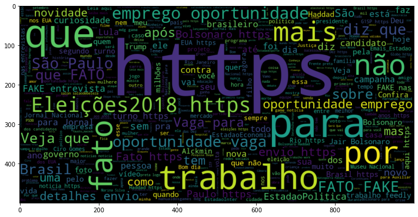

```python
plot_wordcloud(df_analise.loc[df_analise['sentiment'] == 2, 'tweet_text'])
```

**NOTA: A presença de https pode indicar trechos HTML nos tweets (BeautilfulSoup?) ou não... Vamos avaliar.**

```python
# Analisando HTTPS
c = 1
for texto in df_analise.loc[df_analise['tweet_text'].str.contains('https'), 'tweet_text']:
    print(texto)
    c += 1
    if c == 10:
        break
```

```
Gostei de um vídeo @YouTube https://t.co/TBrLMJQnt8 dia vai sentir minha falta :(
Mais uma luta, mais uma Vitória. 👮 #Capitão20123 #Trabalho #AlutaContinua #Eleições #DeputadoEstadual https://t.co/57mQzChM3C
Candidatos intensificam campanha nas redes sociais https://t.co/Dyjd0c5cjM
Gostei de um vídeo @YouTube https://t.co/BjfEnuT1Wk QUE VAMO TESTAR ESSA LIVE :)
Quem mata as pessoas não são as armas, diz Flávio Bolsonaro https://t.co/6Ojbf6GXFG
PT entra com reclamação no CNJ contra Moro após divulgação da delação de Palocci https://t.co/TRyDlUX7Pa
Veja o que é #FATO ou #FAKE na entrevista de Ana Amélia à GloboNews https://t.co/cAYD7nGlFP
#Vaga para Auxiliar de Expedição detalhes e envio de cv em: https://t.co/3S3KfjR7CR #oportunidade #emprego
Explosões de gás causam incêndios em dezenas de casas na região de Boston https://t.co/h2leRmDhIE
```

### Nota: Não temos tags HTML, mas referências para sites. Vamos programar sua remoção, junto com a remoção de stop words e a normalização para minúsculas.

```python
'''
Limpa referências para sites e referências @... dos tweets
'''
def limpar_tweet(texto):

    # Converte palavras em minúsculas
    # Remove stop words
    # Remove as referências @... dos tweets
    # Remove sites http, https e www
    palavras = texto.split(' ')
    novo_texto = []
    for palavra in palavras:
        if not palavra in stop_words:
            palavra = palavra.lower()
            if palavra.find('http') != 0 and palavra.find('www') != 0:
                novo_texto.append(re.sub(r'@\w+', '', palavra))

    return ' '.join(novo_texto)
```

```python
'''
Nova versão da função de tratamento dos dados, aplicando a função limpar_tweet()
'''
def tratamento(df):
    df = df.copy()
    try:
        # Remove a coluna 'id'
        df = df.drop('id', axis=1)
    except:
        # Ignorar: O DataFrame pode já ter sido tratado
        pass

    # Elimina registros sem texto na variável 'tweet_text'
    try:
        df.dropna(inplace=True, subset=['tweet_text'])
    except:
        # Ignorar: O DataFrame pode já ter sido tratado
        pass

    # Ajusta o tipo de dados do campo data
    df['tweet_date'] = pd.to_datetime(df['tweet_date'])

    # Ajusta a coluna-alvo sentimento (que podem não existir)
    try:
        df['sentiment']  = pd.to_numeric(df['sentiment'], downcast='integer')
    except:
        print('Aviso: dataframe nao contem feature "sentiment": ignorando tratamentos.')

    # Aplica todos os tratamentos definidos para o texto
    df['tweet_text'] = df['tweet_text'].apply(limpar_tweet)

    return df
```

```python
df_analise = tratamento(df_analise)
```

### Agora vamos plotar para todos os sentimentos

```
*** negativo ***
```

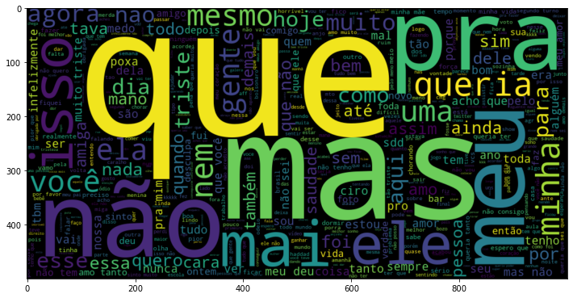

```
*** positivo ***
```

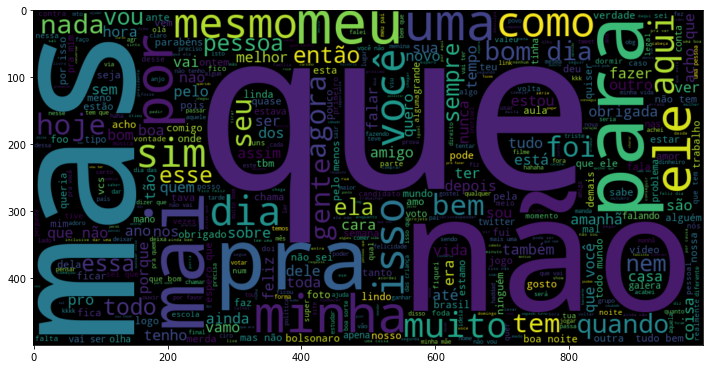

```
*** neutro ***
```

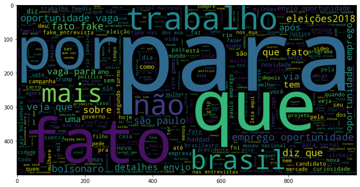

```python
for sentim in range(0,3):
    print(f'*** ' + descr_sentimento(sentim) + ' ***')
    plot_wordcloud(df_analise.loc[df_analise['sentiment'] == sentim, 'tweet_text'])
```

### Algumas análises adicionais de exploração.

```python
import seaborn as sns
```

```python
sns.set_theme()
sns.set()
```

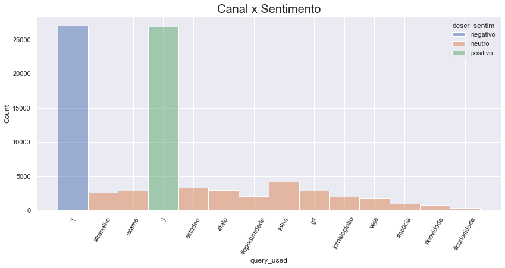

```python
plt.figure(figsize=(14,6))
sns.histplot(data=df_analise[['query_used','descr_sentim','tweet_date']], x='query_used', hue='descr_sentim')
plt.title('Canal x Sentimento', fontsize=20)
plt.xticks(rotation=60)
plt.show()
```

```python
df_analise.groupby(by=['query_used','sentiment']).count()
```

| query_used | sentiment | tweet_text | tweet_date | descr_sentim |
| --- | --- | --- | --- | --- |
| #curiosidade | 2 | 320 | 320 | 320 |
| #fato | 2 | 2938 | 2938 | 2938 |
| #noticia | 2 | 939 | 939 | 939 |
| #novidade | 2 | 793 | 793 | 793 |
| #oportunidade | 2 | 2110 | 2110 | 2110 |
| #trabalho | 2 | 2597 | 2597 | 2597 |
| :( | 0 | 27022 | 27022 | 27022 |
| :) | 1 | 26927 | 26927 | 26927 |
| estadao | 2 | 3295 | 3295 | 3295 |
| exame | 2 | 2894 | 2894 | 2894 |
| folha | 2 | 4214 | 4214 | 4214 |
| g1 | 2 | 2913 | 2913 | 2913 |
| jornaloglobo | 2 | 1991 | 1991 | 1991 |
| veja | 2 | 1788 | 1788 | 1788 |

### Temos uma variável que já determina o sentimento resultante: query_used, conforme constatado.

Como a proposta é construir um modelo que deduza o sentimento através do texto, ignoramos isso.

```python
df_analise['qtd_car'] = df_analise['tweet_text'].str.len()
df_analise['qtd_pal'] = df_analise['tweet_text'].str.split().str.len()
```

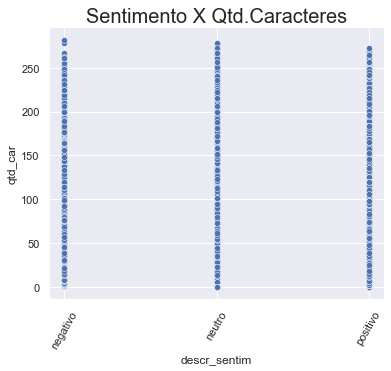

```python
plt.figure(figsize=(6,5))
sns.scatterplot(data=df_analise[['descr_sentim','qtd_car']], x='descr_sentim', y='qtd_car')
plt.title('Sentimento X Qtd.Caracteres', fontsize=20)
plt.xticks(rotation=60)
plt.show()
```

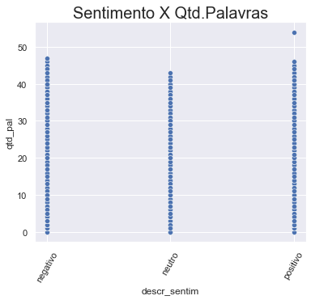

```python
plt.figure(figsize=(6,5))
sns.scatterplot(data=df_analise[['descr_sentim','qtd_pal']], x='descr_sentim', y='qtd_pal')
plt.title('Sentimento X Qtd.Palavras', fontsize=20)
plt.xticks(rotation=60)
plt.show()
```

### Nota: Contagem de letras e palavras não dizem nada sobre o sentimento resultante.

```python
df_analise[['qtd_car','qtd_pal']].describe(percentiles=[.1, .2, .3, .4, .5, .75, .9, .99]).T
```

|  | count | mean | std | min | 10% | 20% | 30% | 40% | 50% | 75% | 90% | 99% | max |
| --- | --- | --- | --- | --- | --- | --- | --- | --- | --- | --- | --- | --- | --- |
| qtd_car | 80741.0 | 69.248907 | 52.152350 | 0.0 | 18.0 | 27.0 | 38.0 | 48.0 | 57.0 | 85.0 | 146.0 | 240.0 | 282.0 |
| qtd_pal | 80741.0 | 10.555752 | 7.382888 | 0.0 | 3.0 | 5.0 | 6.0 | 7.0 | 9.0 | 13.0 | 21.0 | 36.0 | 54.0 |

### A contagem de caracteres e palavras reflete a natureza de textos curtos do Twitter.

```python
from datetime import datetime
```

```python
df_analise['ano_mes'] = df_analise['tweet_date'].apply(lambda x : x.strftime('%Y-%m-%W'))
```

```python
df_analise.sample(10)
```

|  | tweet_text | tweet_date | sentiment | query_used | descr_sentim | qtd_car | qtd_pal | ano_mes |
| --- | --- | --- | --- | --- | --- | --- | --- | --- |
| 44783 | ahaam!!! importante pro meu irmão irmos tbm :... | 2018-10-01 14:06:57+00:00 | 1 | :) | positivo | 83 | 15 | 2018-10-40 |
| 61173 | pedidos elas voltaram capa cadeira praia atoal... | 2018-10-11 16:20:31+00:00 | 2 | #novidade | neutro | 230 | 28 | 2018-10-41 |
| 43855 | hora aventura último episódio vem esse domingo... | 2018-09-22 21:00:13+00:00 | 2 | #noticia | neutro | 102 | 14 | 2018-09-38 |
| 83757 | aquele momento apega alguém pessoa afasta :( | 2018-10-02 00:09:33+00:00 | 0 | :( | negativo | 44 | 7 | 2018-10-40 |
| 29702 | tartaruga ferida reaprende nadar após 'intensi... | 2018-10-02 21:15:00+00:00 | 2 | g1 | neutro | 70 | 10 | 2018-10-40 |
| 52914 | diz que profundo como oceano, mas fato que voc... | 2018-10-03 02:32:09+00:00 | 1 | :) | positivo | 66 | 13 | 2018-10-40 |
| 76314 | datafolha df: ibaneis (mdb) chega 32%; eliana ... | 2018-10-04 22:43:35+00:00 | 2 | veja | neutro | 60 | 10 | 2018-10-40 |
| 69026 | ainda solução, cara. você tranquilizou vários... | 2018-10-03 17:58:04+00:00 | 1 | :) | positivo | 203 | 28 | 2018-10-40 |
| 44810 | 🌸🌸🌸terça dia #lançamentos nova coleção está li... | 2018-09-19 21:10:12+00:00 | 2 | #novidade | neutro | 227 | 34 | 2018-09-38 |
| 54959 | bloqueia aqui também! :d | 2018-10-08 11:50:47+00:00 | 1 | :) | positivo | 25 | 4 | 2018-10-41 |

```python
gb = df_analise.groupby(by=['ano_mes','descr_sentim']).count()
df_gb = gb.reset_index()
df_gb.head(3)
```

|  | ano_mes | descr_sentim | tweet_text | tweet_date | sentiment | query_used | qtd_car | qtd_pal |
| --- | --- | --- | --- | --- | --- | --- | --- | --- |
| 0 | 2018-08-32 | neutro | 1 | 1 | 1 | 1 | 1 | 1 |
| 1 | 2018-08-33 | neutro | 513 | 513 | 513 | 513 | 513 | 513 |
| 2 | 2018-08-34 | neutro | 1648 | 1648 | 1648 | 1648 | 1648 | 1648 |

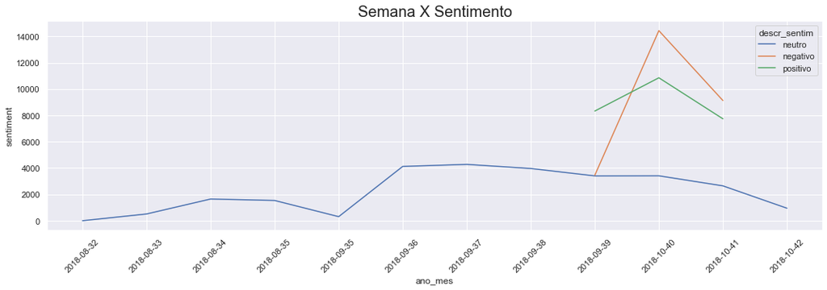

```python
plt.figure(figsize=(18,5))
sns.lineplot(data=df_gb, x='ano_mes', hue='descr_sentim', y='sentiment')
plt.title('Semana X Sentimento', fontsize=20)
plt.xticks(rotation=45)
plt.show()
```

## Nota: Obervamos que há uma questão temporal nos dados

Uma eventual seleção Treino x Validação out-of-time pode produzir uma base de validação contendo apenas tweets neutros.

## O gráfico a seguir comprova...

**...a concentração de tweets entre o final de setembro e outubro.**

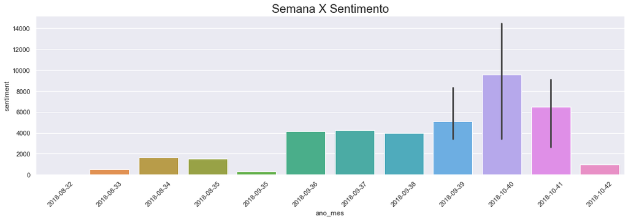

```python
plt.figure(figsize=(18,5))
sns.barplot(data=df_gb, x='ano_mes', y='sentiment')
plt.title('Semana X Sentimento', fontsize=20)
plt.xticks(rotation=45)
plt.show()
```

```python
df_gb = None        # Não é mais necessária
```

# Testes e Seleção do Modelo NLP

### Primeiro Passo: Separação das bases de Treino e Validação

```python
df_treino, df_valid = train_test_split(df_analise, test_size=0.1)

X_treino, y_treino = df_treino['tweet_text'], df_treino['sentiment']
X_valid , y_valid  = df_valid['tweet_text' ], df_valid['sentiment' ]

print('Shape Treino - X:', X_treino.shape, 'Y:', y_treino.shape)
print('Shape Valid. - X:', X_valid.shape , 'Y:', y_valid.shape )
```

```
Shape Treino - X: (72666,) Y: (72666,)
Shape Valid. - X: (8075,) Y: (8075,)
```

```python
df_analise = None    # Não é mais necessária
```

## Algunas funções utilitárias

### Função para exibir métricas

```python
from sklearn.metrics import accuracy_score, precision_score, recall_score
```

```python
'''
Calcula as métricas de uma base de teste ou de bases de treino e validação.
'''
def metricas(y, y_pred, y_valid=None, y_valid_pred=None):

    acc  =  accuracy_score(y, y_pred)
    prec = precision_score(y, y_pred, average='weighted')
    rec  =    recall_score(y, y_pred, average='weighted')

    # Retornará os resultados calculados para uso posterior
    str_teste  = ''
    str_treino = ''
    str_valid  = ''
    if (y_valid is None):
        str_teste = f'Teste:\nAcc: {acc:.3f}, Precision: {prec:.3f}, Recall: {rec:.3f}'
        print(str_teste)
    else:
        acc_valid  =  accuracy_score(y_valid, y_valid_pred)
        prec_valid = precision_score(y_valid, y_valid_pred, average='weighted')
        rec_valid  =    recall_score(y_valid, y_valid_pred, average='weighted')

        str_treino = f'Treino...:\nAcc: {acc:.3f}, Precision: {prec:.3f}, Recall: {rec:.3f}'
        print(str_treino)
        str_valid = f'Validação:\nAcc: {acc_valid:.3f}, Precision: {prec_valid:.3f}, Recall: {rec_valid:.3f}'
        print(str_valid)

    return str_treino, str_valid, str_teste
```

### Função para exibir a matriz de confusão

```python
from mlxtend.plotting import plot_confusion_matrix
from sklearn.metrics import confusion_matrix
```

```python
'''
Plota o gráfico matriz de confusão de uma base Y e Y predita
'''
def matriz_conf(y, y_pred):
    cm = confusion_matrix(y, y_pred)
    plt.figure(figsize=(12,12))
    plot_confusion_matrix(conf_mat=cm)
    plt.show()
```

### Função para executar um modelo de predição e apresentar métricas e matriz de confusão

```python
import time

'''
Executa um modelo de predição com as bases especificadas.
Se X_Valid e y_valid forem especificados, entao a função entende que foi executada na fase de treino e faz o FIT
do modelo antes das predições. Caso contrário, o modelo entende ser uma predição de teste e não faz o FIT
'''
def exec_modelo(modelo, X, y=None, X_valid=None, y_valid=None, zerar_valid=True):

    str_tempo = ''

    if X_valid is not None:
        # Fase de treino: FIT do modelo e predição para a base de validação
        print("Realizando FIT do modelo...")
        inicio = time.time()
        modelo.fit(X, y)
        fim = time.time()
        str_tempo = 'Tempo de treinamento do modelo: {}s'.format(fim - inicio)
        print(str_tempo)
        print()
        print('Realizando Predições da base de validacao...')
        y_valid_pred = modelo.predict(X_valid)

    # Predição da base X, que pode ser a base de treino ou a base de teste
    print('Realizando Predições da base de treino/teste...')
    y_pred = modelo.predict(X)

    # Apresenta as métricas e matriz de confusão somente de "y´s" forem fornecidos
    str_treino = ''
    str_valid  = ''
    str_teste  = ''
    if y is not None:
        if y_valid_pred is not None:
            print("Resultados do Treinamento:")
            str_treino, str_valid, str_teste = metricas(y, y_pred, y_valid, y_valid_pred)
            matriz_conf(y_valid, y_valid_pred)
            if zerar_valid:
                y_valid_pred = None
        else:
            print("Resultados da Validação:")
            str_treino, str_valid, str_teste = metricas(y, y_pred)
            matriz_conf(y, y_pred)

    print("Modelo executado.")

    return y_pred, str_tempo, str_treino, str_valid, str_teste
```

## BagOfWords

```python
from sklearn.feature_extraction.text import CountVectorizer

vectr = CountVectorizer(max_features=10000, stop_words=stop_words)
vectr.fit(X_treino)
```

```
CountVectorizer(max_features=10000,
                stop_words=['!', '!!', '!?', '!”', '!🎶', '"', '",', '"-', '"0',
                            '"3', '"5', '"A', '"E', '"I', '"N', '"O', '"Y',
                            '"a', '"e', '"n', '"o', '"q', '"À', '"É', '"é',
                            '"ó', '"🙄', '#', '#1', '#2', ...])
```

```python
X_treino_bow, X_valid_bow = vectr.transform(X_treino).toarray(), vectr.transform(X_valid).toarray()

print('Treino:', X_treino_bow.shape)
print('Valid.:', X_valid_bow.shape)
```

```
Treino: (72666, 10000)
Valid.: (8075, 10000)
```

## Testando alguns modelos

```python
from sklearn.naive_bayes import MultinomialNB
from sklearn.ensemble import RandomForestClassifier
from lightgbm import LGBMClassifier
```

### Naive Bayes

```python
modelo = MultinomialNB()
```

```
Realizando FIT do modelo...
Tempo de treinamento do modelo: 88.24023842811584s

Realizando Predições da base de validacao...
Realizando Predições da base de treino/teste...
Resultados do Treinamento:
Treino...:
Acc: 0.819, Precision: 0.820, Recall: 0.819
Validação:
Acc: 0.784, Precision: 0.783, Recall: 0.784
```

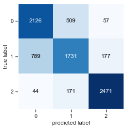

```
Modelo executado.
```

```python
# exec_modelo() retorna o y_pred, tempo de treinamento, métricas de treino, validação e teste.
# vamos salvar de cada modelo testado para facilitar a revisão ao final.
_, tempo_bow_nb, treino_bow_nb, valid_bow_nb, _ = exec_modelo(modelo, X_treino_bow, y_treino, X_valid_bow, y_valid)
```

### Random Forest

```python
modelo = RandomForestClassifier(n_estimators=200, max_depth=3, n_jobs=8, random_state=12)
```

```
Realizando FIT do modelo...
Tempo de treinamento do modelo: 28.386947870254517s

Realizando Predições da base de validacao...
Realizando Predições da base de treino/teste...
Resultados do Treinamento:
Treino...:
Acc: 0.667, Precision: 0.696, Recall: 0.667
Validação:
Acc: 0.654, Precision: 0.685, Recall: 0.654
```

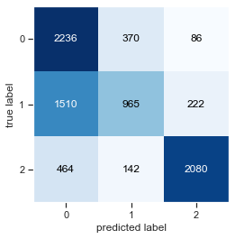

```
Modelo executado.
```

```python
_, tempo_bow_rf, treino_bow_rf, valid_bow_rf, _ = exec_modelo(modelo, X_treino_bow, y_treino, X_valid_bow, y_valid)
```

### LightGBM

```python
modelo = LGBMClassifier(n_estimators=200, max_depth=3, n_jobs=8, random_state=12)
```

```
Realizando FIT do modelo...
Tempo de treinamento do modelo: 9.173457622528076s

Realizando Predições da base de validacao...
Realizando Predições da base de treino/teste...
Resultados do Treinamento:
Treino...:
Acc: 0.720, Precision: 0.748, Recall: 0.720
Validação:
Acc: 0.710, Precision: 0.739, Recall: 0.710
```

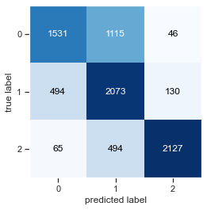

```
Modelo executado.
```

```python
_, tempo_bow_lg, treino_bow_lg, valid_bow_lg, _ = exec_modelo(modelo, X_treino_bow, y_treino, X_valid_bow, y_valid)
```

## Vamos definir nossa classe classificadora customizada

**Baseado na função de classificação por emoticons criada anteriormente**

```python
import numpy as np
'''
Classificador customizado (bastante singelo) que retorna o sentimento com base na presença de
emoticons positivos e/ou negativos.
'''
class EmoticonClassifier:

    def __init__(self):

        self._X = None
        self._y = None
        self._fitted = False


    def fit(self, x, y):

        self._X = x
        self._y = y
        self._fitted = True


    def predict(self, x):

        if not self._fitted:
            print('Model not fitted.')
            return None
        else:
            y_pred = np.array([], dtype='int8')
            for texto in x:
                y_pred = np.append(y_pred, previsao_emoticons(texto))

            return y_pred
```

**Executando o modelo customizado...**

```python
modelo = EmoticonClassifier()
```

```
Realizando FIT do modelo...
Tempo de treinamento do modelo: 0.0s

Realizando Predições da base de validacao...
Realizando Predições da base de treino/teste...
Resultados do Treinamento:
Treino...:
Acc: 0.819, Precision: 0.873, Recall: 0.819
Validação:
Acc: 0.825, Precision: 0.877, Recall: 0.825
```

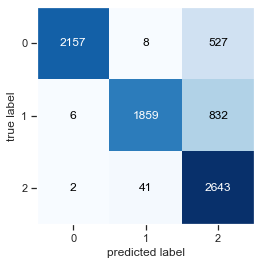

```
Modelo executado.
```

```python
_, tempo_bow_cm, treino_bow_cm, valid_bow_cm, _ = exec_modelo(modelo, X_treino, y_treino, X_valid, y_valid)
```

```python
vectr = None
modelo = None
X_treino_bow = None
X_valid_bow = None
```

# TF-IDF

```python
from sklearn.feature_extraction.text import TfidfVectorizer

vectr_idf = TfidfVectorizer(max_features=10000, stop_words=stop_words)
vectr_idf.fit(X_treino)
```

```
TfidfVectorizer(max_features=10000,
                stop_words=['!', '!!', '!?', '!”', '!🎶', '"', '",', '"-', '"0',
                            '"3', '"5', '"A', '"E', '"I', '"N', '"O', '"Y',
                            '"a', '"e', '"n', '"o', '"q', '"À', '"É', '"é',
                            '"ó', '"🙄', '#', '#1', '#2', ...])
```

```python
X_treino_idf, X_valid_idf = vectr_idf.transform(X_treino).toarray(), vectr_idf.transform(X_valid).toarray()

print('Treino:', X_treino_idf.shape)
print('Valid.:', X_valid_idf.shape )
```

```
Treino: (72666, 10000)
Valid.: (8075, 10000)
```

### Naive Bayes

```python
modelo = MultinomialNB()
```

```
Realizando FIT do modelo...
Tempo de treinamento do modelo: 2.796049118041992s

Realizando Predições da base de validacao...
Realizando Predições da base de treino/teste...
Resultados do Treinamento:
Treino...:
Acc: 0.820, Precision: 0.821, Recall: 0.820
Validação:
Acc: 0.778, Precision: 0.778, Recall: 0.778
```

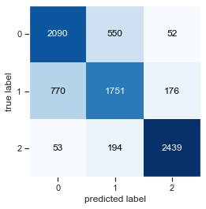

```
Modelo executado.
```

```python
_, tempo_idf_rf, treino_idf_nb, valid_idf_nb, _ = exec_modelo(modelo, X_treino_idf, y_treino, X_valid_idf, y_valid)
```

### Random Forest

```python
modelo = RandomForestClassifier(n_estimators=200, max_depth=3, n_jobs=8, random_state=12)
```

```
Realizando FIT do modelo...
Tempo de treinamento do modelo: 26.47352170944214s

Realizando Predições da base de validacao...
Realizando Predições da base de treino/teste...
Resultados do Treinamento:
Treino...:
Acc: 0.688, Precision: 0.696, Recall: 0.688
Validação:
Acc: 0.684, Precision: 0.692, Recall: 0.684
```

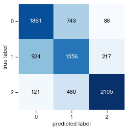

```
Modelo executado.
```

```python
_, tempo_idf_nb, treino_idf_rf, valid_idf_rf, _ = exec_modelo(modelo, X_treino_idf, y_treino, X_valid_idf, y_valid)
```

### LightGBM

```python
modelo = LGBMClassifier(n_estimators=200, max_depth=3, n_jobs=8, random_state=12)
```

```
Realizando FIT do modelo...
Tempo de treinamento do modelo: 15.049388647079468s

Realizando Predições da base de validacao...
Realizando Predições da base de treino/teste...
Resultados do Treinamento:
Treino...:
Acc: 0.728, Precision: 0.755, Recall: 0.728
Validação:
Acc: 0.715, Precision: 0.743, Recall: 0.715
```

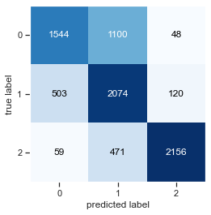

```
Modelo executado.
```

```python
_, tempo_idf_lg, treino_idf_lg, valid_idf_lg, _ = exec_modelo(modelo, X_treino_idf, y_treino, X_valid_idf, y_valid)
```

```python
vectr_idf = None
modelo = None
X_treino_idf = None
X_valid_idf = None
```

# Word Embedding

**Criação dos vetores**

```python
from gensim.models import Word2Vec
from gensim.utils import simple_preprocess
```

```python
'''
Quebra textos em palavras
'''
def tokenize(texto, m_len=3):
    novo_texto = simple_preprocess(texto, min_len=m_len)

    return novo_texto
```

**Cálculo de similaridade das diferentes palavras via Word2Vec**

```python
# Definindo o tamanho do vetor utilizado no modelo de embedding e na rede neural
TAM_VETOR=80
```

```python
modelo_w2v = Word2Vec(sentences = X_treino.apply(lambda t: tokenize(t)),
                      vector_size = TAM_VETOR,
                      window = 7,
                      min_count = 1,
                      workers = 3)
```

**Alguns testes para avaliar a performance dos agrupamentos**

```python
modelo_w2v.wv.most_similar('ótimo')[:5]
```

```
[('booom', 0.9392982125282288),
 ('bom', 0.9340139627456665),
 ('começando', 0.9256890416145325),
 ('cansativo', 0.9221374988555908),
 ('inteiro', 0.9202582836151123)]
```

```python
modelo_w2v.wv.most_similar('ruim')[:5]
```

```
[('legal', 0.9665572643280029),
 ('difícil', 0.9635748267173767),
 ('complicado', 0.9629555344581604),
 ('longe', 0.9622583389282227),
 ('foda', 0.9552310109138489)]
```

```python
modelo_w2v.wv.most_similar('não')[:5]
```

```
[('nem', 0.9258705377578735),
 ('nunca', 0.8844177722930908),
 ('absolutamente', 0.8841944336891174),
 ('nao', 0.8839237689971924),
 ('pior', 0.8763203024864197)]
```

### Visualização da distribuição das palavras num plano cartesiano

De: https://towardsdatascience.com/a-beginners-guide-to-word-embedding-with-gensim-word2vec-model-5970fa56cc92

```python
from sklearn.manifold import TSNE
```

```python
'''
Exibe um gráfico de distribuição de palavras num plano cartesiano
'''
def grafico_palavras(modelo, palavra):

    # Array de dados float
    arr = np.empty((0, TAM_VETOR), dtype='f')
    # Uma lista de palavras
    palavras = [palavra]
    # Obtem as palavras mais similares de uma dada amostra
    proximas = modelo.similar_by_word(palavra)
    # Constróis um array de arrays com as palavras e suas próximas
    arr = np.append(arr, np.array([modelo[palavra]]), axis=0)
    # Constrói o array de vetores
    for score in proximas:
        vetor_palavras = modelo[score[0]]
        palavras.append(score[0])
        arr = np.append(arr, np.array([vetor_palavras]), axis=0)

    # Instancia o objeto produtor de dados para o gráfico
    tsne = TSNE(n_components=2, random_state=0)
    np.set_printoptions(suppress=True)
    # Cálculo dos pontos do gráfico para os vetores obtidos
    Y = tsne.fit_transform(arr)
    coords_x = Y[:, 0]
    coords_y = Y[:, 1]

    # Gera o gráfico
    plt.figure(figsize=(6,6))
    plt.scatter(coords_x, coords_y)
    # Adiciona a palavra relacionada com cada ponto
    for palavra, x, y in zip(palavras, coords_x, coords_y):
        plt.annotate(palavra, xy=(x, y), xytext=(0, 0), textcoords='offset points')
    # Garante uma pequena distância em cada ponto
    plt.xlim(coords_x.min()+0.0005, coords_x.max()+0.0005)
    plt.ylim(coords_y.min()+0.0005, coords_y.max()+0.0005)
    plt.show()
```

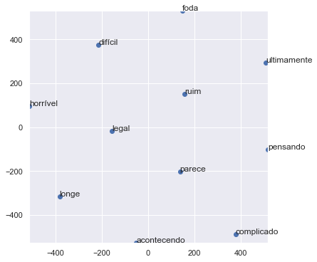

```python
grafico_palavras(modelo_w2v.wv, 'ruim')
```

### Keras

```python
from keras.preprocessing.sequence import pad_sequences
from tensorflow import keras
from tensorflow.keras import layers
from tqdm import tqdm
```

```python
'''
Retorna duas lista: tokens e índices correspondentes
'''
def get_vocab(modelo_w2v):
    word2id = {}
    id2word = {}

    for index, word in enumerate(tqdm(modelo_w2v.wv.key_to_index)):
        word2id[   word  ] = index + 1
        id2word[index + 1] = word

    return word2id, id2word
```

```python
'''
Retorna um array NumPy contendo ids dos tokens informados
'''
def seq_to_id(sequence, vocabulary):

    ids = []
    nao_enc = len(vocabulary)     # Evita repetidas chamadas para len()
    for word in sequence:
        ids.append(vocabulary[word] if word in vocabulary else nao_enc)

    return np.array(ids)
```

```python
vocab, id2word = get_vocab(modelo_w2v)
```

```python
X_treino_seq = X_treino.apply(tokenize).apply(lambda s: seq_to_id(s, vocab))
X_valid_seq  = X_valid.apply( tokenize).apply(lambda s: seq_to_id(s, vocab))
```

```python
X_treino_seq.head()
```

```
77620    [17584, 16149, 10, 5933, 341, 341, 111, 5, 43,...
3015       [7, 3017, 101, 56, 607, 1, 7132, 146, 56, 2544]
43295    [327, 188, 167, 92, 11, 79, 11, 119, 3957, 5, ...
38007          [3950, 4, 14, 933, 2, 67, 1187, 67, 1, 899]
51533    [203, 48, 10, 15, 208, 29, 2, 31, 4590, 1385, ...
Name: tweet_text, dtype: object
```

```python
# Parâmetro para truncamento e padding
MAX_LENGTH = 100
```

**Padronização do tamanho das amostras**

```python
X_treino_seq = pad_sequences(X_treino_seq, padding='post', truncating='post', maxlen=MAX_LENGTH)
X_valid_seq  = pad_sequences(X_valid_seq , padding='post', truncating='post', maxlen=MAX_LENGTH)
```

```python
X_treino_seq.shape
```

```
(72666, 100)
```

```python
X_treino_seq
```

```
array([[17584, 16149,    10, ...,     0,     0,     0],
       [    7,  3017,   101, ...,     0,     0,     0],
       [  327,   188,   167, ...,     0,     0,     0],
       ...,
       [   86, 19589,  1547, ...,     0,     0,     0],
       [   48,    94,   156, ...,     0,     0,     0],
       [   55,    48,   123, ...,     0,     0,     0]])
```

**Encoding dos valores de validação: O modelo espera que os resultados estejam entrem 0 e 1**

```python
'''
Transforma 0, 1 e 2 em 0, 0.5 e 1, respectivamente, como esperado pelo modelo
'''
def encode_y(y):

    return y.copy().apply(lambda x: float(x) / 2)
```

```python
y_treino_enc = encode_y(y_treino)
y_valid_enc  = encode_y(y_valid)
```

```python
print('y_treino_enc:')
print(y_treino_enc)
print()
print('y_valid_enc:')
print(y_valid_enc)
```

```
y_treino_enc:
77620    0.5
3015     0.0
43295    0.0
38007    0.5
51533    0.0
        ...
74524    0.5
43905    1.0
28408    0.0
50187    0.5
60531    0.0
Name: sentiment, Length: 72666, dtype: float64

y_valid_enc:
47225    1.0
28334    0.0
63335    0.5
70788    1.0
33002    1.0
        ...
69442    0.0
8275     0.5
15049    1.0
16797    0.5
58220    0.0
Name: sentiment, Length: 8075, dtype: float64
```

**Rede Neural**

```python
modelo = keras.Sequential(
    [
        layers.Embedding(len(vocab)+1, TAM_VETOR, trainable=True, input_length=MAX_LENGTH, mask_zero=True, name="emb"),
        layers.Lambda(lambda x: keras.backend.mean(x, axis=1)),
        layers.Dense(TAM_VETOR, activation="relu", name="layer2"),
        layers.Dense(1, activation="sigmoid"),
    ]
)
```

```python
modelo.summary()
```

```
Model: "sequential"
_________________________________________________________________
 Layer (type)                Output Shape              Param #
=================================================================
 emb (Embedding)             (None, 100, 80)           4155360

 lambda (Lambda)             (None, 80)                0

 layer2 (Dense)              (None, 80)                6480

 dense (Dense)               (None, 1)                 81

=================================================================
Total params: 4,161,921
Trainable params: 4,161,921
Non-trainable params: 0
_________________________________________________________________
```

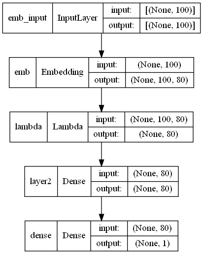

```python
keras.utils.plot_model(modelo, show_shapes=True)
```

**Compilação do modelo**

```python
modelo.compile(
    optimizer=keras.optimizers.Adam(learning_rate=0.001),
    loss=keras.losses.BinaryCrossentropy(),
    metrics=[keras.metrics.BinaryAccuracy()],
)
```

**Treino do modelo**

```python
print("Treino do modelo")
inicio = time.time()
modelo.fit(
    X_treino_seq,
    y_treino_enc,
    batch_size=100,
    epochs=1,
    validation_data=(X_valid_seq, y_valid_enc),
    use_multiprocessing=True
)
fim = time.time()
tempo_we = 'Tempo de treinamento do modelo: {}s'.format(fim - inicio)
```

```
Treino do modelo
```

**Execução do modelo**

Os resultados estarão na forma do "hot encoding", então devemos decodificar.

```python
'''
Decodifica as previsões para os valores 0, 1 e 2.
Como a previsão vem como um float entre 0 e 1, utilizamos a divisão customizada para decodificar:
Entre 0.00 e 0.39 -> 0
Entre 0.40 e 0.59 -> 1
Entre 0.60 e 1.00 -> 2
'''
def decode_y(y):

    novo_y = []
    for x in y:
        novo_y.append(0 if x < 0.40 else 1 if x < 0.60 else 2)
    return np.array(novo_y)
```

```python
y_treino_pred = decode_y(modelo.predict(X_treino_seq).reshape(-1))
y_valid_pred  = decode_y(modelo.predict(X_valid_seq ).reshape(-1))

print('Treino...:', y_treino_pred.shape)
print('Validacao:', y_valid_pred.shape )
```

```
Treino...: (72666,)
Validacao: (8075,)
```

```python
print(y_treino_pred)
print(y_valid_pred)
```

```
[0 0 0 ... 0 0 0]
[2 0 0 ... 2 1 0]
```

**Resultados**

```python
treino_we, valid_we, _ = metricas(y_treino, y_treino_pred, y_valid, y_valid_pred)
```

```
Treino...:
Acc: 0.730, Precision: 0.770, Recall: 0.730
Validação:
Acc: 0.709, Precision: 0.736, Recall: 0.709
```

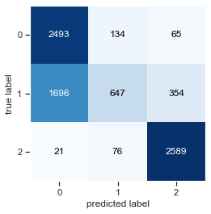

```python
matriz_conf(y_valid, y_valid_pred)
```

```python
modelo_w2v    = None
vocab         = None
id2word       = None
X_treino_seq  = None
X_valid_seq   = None
y_treino_enc  = None
y_valid_enc   = None
modelo        = None
y_treino_pred = None
y_valid_pred  = None
```

## Conclusão sobre os modelos:

Levando em conta os resultados sem otimização dos hiperparâmetros dos modelos:

**BagOfWords com Naive Bayes**:

```python
print(tempo_bow_nb, '\n', treino_bow_nb, '\n', valid_bow_nb)
```

```
Tempo de treinamento do modelo: 88.24023842811584s
 Treino...:
Acc: 0.819, Precision: 0.820, Recall: 0.819
 Validação:
Acc: 0.784, Precision: 0.783, Recall: 0.784
```

**BagOfWords com Random Forest**:

```python
print(tempo_bow_rf, '\n', treino_bow_rf, '\n', valid_bow_rf)
```

```
Tempo de treinamento do modelo: 28.386947870254517s
 Treino...:
Acc: 0.667, Precision: 0.696, Recall: 0.667
 Validação:
Acc: 0.654, Precision: 0.685, Recall: 0.654
```

**BagOfWords com LightGBM:**

```python
print(tempo_bow_lg, '\n', treino_bow_lg, '\n', valid_bow_lg)
```

```
Tempo de treinamento do modelo: 9.173457622528076s
 Treino...:
Acc: 0.720, Precision: 0.748, Recall: 0.720
 Validação:
Acc: 0.710, Precision: 0.739, Recall: 0.710
```

**BagOfWords com Classificador Customizado:**

```python
print(tempo_bow_cm, '\n', treino_bow_cm, '\n', valid_bow_cm)
```

```
Tempo de treinamento do modelo: 0.0s
 Treino...:
Acc: 0.819, Precision: 0.873, Recall: 0.819
 Validação:
Acc: 0.825, Precision: 0.877, Recall: 0.825
```

**TF-IDF com Naive Bayes**:

```python
print(tempo_idf_nb, '\n', treino_idf_nb, '\n', valid_idf_nb)
```

[output not shown]

**TF-IDF com Random Forest**:

```python
print(tempo_idf_rf, '\n', treino_idf_rf, '\n', valid_idf_rf)
```

[output not shown]

**TF-IDF com LightGBM**:

```python
print(tempo_idf_lg, '\n', treino_idf_lg, '\n', valid_idf_lg)
```

```
Tempo de treinamento do modelo: 15.049388647079468s
 Treino...:
Acc: 0.728, Precision: 0.755, Recall: 0.728
 Validação:
Acc: 0.715, Precision: 0.743, Recall: 0.715
```

**Word Embedding com Keras**:

```python
print(tempo_we, '\n', treino_we, '\n', valid_we)
```

```
Tempo de treinamento do modelo: 35.20295763015747s
 Treino...:
Acc: 0.730, Precision: 0.770, Recall: 0.730
 Validação:
Acc: 0.709, Precision: 0.736, Recall: 0.709
```

Verifica-se que BagOfWords com nosso modelo customizado obteve os melhores resultados, seguido de BagOfWords com Naive Bayes.  
São modelos com poucas opções de customização de hiperparâmetros. De fato, nosso classificador customizado nem os têm.  
Vamos explorar um pouco BOW com NB, e algumas tentativas com Word Embeddings.

# Otimização do modelo BagOfWords com NB

Antes de executar, forçamos a limpeza do "lixo"

```python
import gc
gc.collect()
```

```
6163
```

### GridSearch

```python
from sklearn.model_selection import GridSearchCV
```

**Recriando os modelos e dados necessários**

```python
# Para o GridSearch vamos limitar o número de features devido o consumo de memória
vectr = CountVectorizer(max_features=4000, stop_words=stop_words)
vectr.fit(X_treino)

X_treino_bow, X_valid_bow = vectr.transform(X_treino).toarray(), vectr.transform(X_valid).toarray()
print('Treino:', X_treino_bow.shape)
print('Valid.:', X_valid_bow.shape)
```

```
Treino: (72666, 4000)
Valid.: (8075, 4000)
```

```python
# Transformação com o novo limite de fatures
X_treino_bow = vectr.transform(X_treino).toarray()
```

```python
# Instância para usar com o GridSearch
modelo = MultinomialNB()
```

```python
# Parâmetros a testar
parameters = {
    'alpha': [1.0, 0.8, 0.6, 0.4, 0.2],
    'fit_prior': [True, False]
}
```

```python
# Execução dos testes
gs = GridSearchCV(modelo, parameters, scoring='accuracy', verbose=3, n_jobs=-1, cv=2)
gs.fit(X_treino_bow[:20000], y_treino[:20000])
```

```
Fitting 2 folds for each of 10 candidates, totalling 20 fits
```

```
GridSearchCV(cv=2, estimator=MultinomialNB(), n_jobs=-1,
             param_grid={'alpha': [1.0, 0.8, 0.6, 0.4, 0.2],
                         'fit_prior': [True, False]},
             scoring='accuracy', verbose=3)
```

```python
# Melhores parâmetros
gs.best_params_
```

```
{'alpha': 0.8, 'fit_prior': True}
```

```python
# Modelo com os melhores parâmetros definidos por GridSearchCV
modelo = gs.best_estimator_
```

```python
# Recriando o modelo com a quantidade de features original (utilizada na comparação com outros modelos)
vectr = CountVectorizer(max_features=10000, stop_words=stop_words)
vectr.fit(X_treino)
```

```
CountVectorizer(max_features=10000,
                stop_words=['!', '!!', '!?', '!”', '!🎶', '"', '",', '"-', '"0',
                            '"3', '"5', '"A', '"E', '"I', '"N', '"O', '"Y',
                            '"a', '"e', '"n', '"o', '"q', '"À', '"É', '"é',
                            '"ó', '"🙄', '#', '#1', '#2', ...])
```

```python
# Recriando as bases de treino transformadas
X_treino_bow = vectr.transform(X_treino).toarray()
X_valid_bow  = vectr.transform(X_valid).toarray()
```

```
Realizando FIT do modelo...
Tempo de treinamento do modelo: 80.5056164264679s

Realizando Predições da base de validacao...
Realizando Predições da base de treino/teste...
Resultados do Treinamento:
Treino...:
Acc: 0.820, Precision: 0.821, Recall: 0.820
Validação:
Acc: 0.784, Precision: 0.783, Recall: 0.784
```

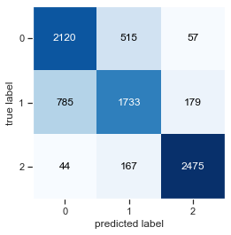

```
Modelo executado.
```

```python
# Execução com os dados de Treino e Validação
_, tempo_bow_nb, treino_bow_nb, valid_bow_nb, _ = exec_modelo(modelo, X_treino_bow, y_treino, X_valid_bow, y_valid)
```